# Practical 1: Simple and Multiple Linear Regression

Dr. Jos Hageman  
Mathematical & Statistical Methods group – Biometris  
Wageningen University & Research

jos.hageman@wur.nl

### Packages

This practical does not rely on any external packages.

## Exercises

### Exercise 1: Weight gain of chickens

A researcher conducts an experiment to examine the relationship between the weight gain of chickens whose diets had been supplemented by different amounts of amino acid lysine and the amount of lysine ingested. Since the percentage of lysine is known, and we can monitor the amount of feed consumed, we can determine the amount of lysine eaten. A random sample of twelve 2-week-old chickens was selected for the study. Each was caged separately and was allowed to eat at will from feed composed of a base supplemented with lysine.

First we will introduce the data into R and make a plot to visualize it.

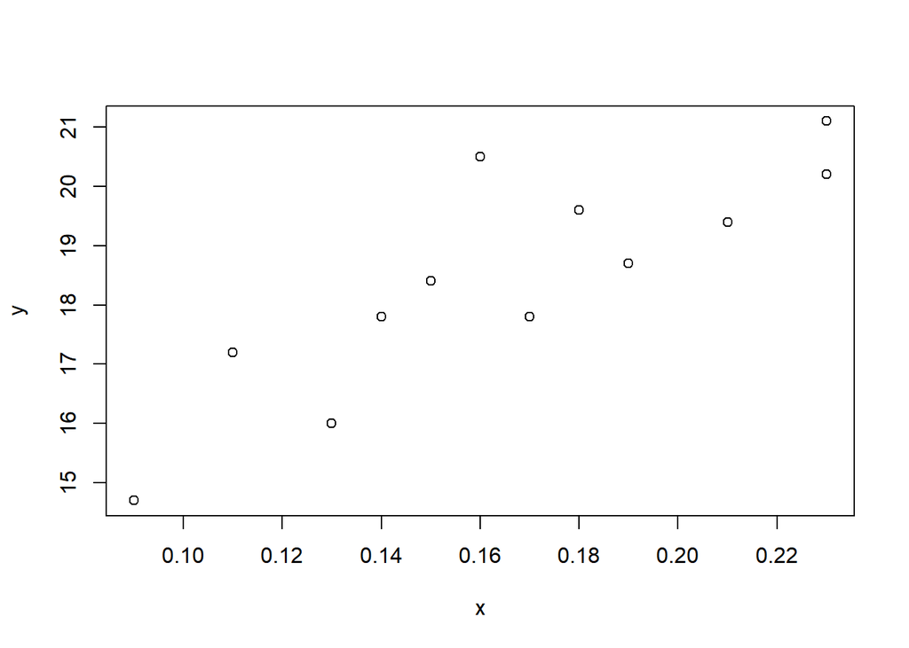

```r
# weight gain y of chickens with amount of lysine x ingested
y <- c(14.7, 17.8, 19.6, 18.4, 20.5, 21.1, 17.2, 18.7, 20.2, 16.0, 17.8, 19.4)
x <- c(0.09, 0.14, 0.18, 0.15, 0.16, 0.23, 0.11, 0.19, 0.23, 0.13, 0.17, 0.21)

# plot the data
plot(x, y)
```

1. Take a good look at the scatterplot of x versus y. Give an estimate of the correlation coefficient between x and y. Explain the sign and give and estimate of the magnitude.
1. There is a positive trend in the plot. If x increases y increases as well. This means the correlation coefficient has a positive (+) sign. The magnitude is a bit more difficult to estimate by eye, but given that the data points lie reasonably close to an imaginary line, I estimate the correlation coefficient to be around 0.8 which is reasonably close to the actual value of 0.85.

Next we will calculate the correlation coefficient.

```r
cor(x, y)
```

```
[1] 0.8521698
```

2. Compare the calculated correlation coefficient estimate with your own estimate from the previous exercise. Was your estimate close? what about the sign?
2. Depending on your estimate your value might be close or somewhat further away from the calculated value. Your estimated sign should positive as the trend is clearly positive.

Correlation coefficients describe the linear association between two variables. With linear regression we want to model this relationship. This is what we will do next. We create a simple linear regression model, modelling weight gain as a function of lysine ingested. We will also ask for summary output for this model.

```r
# the simple regression model
weightgain <- lm(y ~ x)

# summary output for estimates, standard error, ...
summary(weightgain)
```

```
Call:
lm(formula = y ~ x)

Residuals:
    Min      1Q  Median      3Q     Max
-1.1662 -0.6741 -0.1367  0.5486  2.2590

Coefficients:
            Estimate Std. Error t value Pr(>|t|)
(Intercept)   12.509      1.192   10.50 1.02e-06 ***
x             35.828      6.957    5.15 0.000431 ***
---
Signif. codes:  0 '***' 0.001 '**' 0.01 '*' 0.05 '.' 0.1 ' ' 1

Residual standard error: 1.034 on 10 degrees of freedom
Multiple R-squared:  0.7262,    Adjusted R-squared:  0.6988
F-statistic: 26.52 on 1 and 10 DF,  p-value: 0.0004315
```

3. From the summary output provide estimates and standard errors for the intercept and slope
4. The estimated equation or prediction equation: *ŷ* = … + …*x.
3. For the intercept: estimate: *β*<sub>0</sub> = 12.509; standard error SE(*β*<sub>0</sub>) = 1.192; For the slope : estimate: *β*<sub>1</sub> = 35.828; standard error: SE(*β*<sub>1</sub>) = 6.957;
4. Estimated regression equation: *ŷ* = 12.509 + 35.828*x

Next we want to study the different sum of squares from the ANOVA table. Slightly problematic is that in R, in an ANOVA table no sum of squares for the total is given. However we can calculate the sum of squares ourselves quite easily. Run the following code to get the ANOVA table.

```r
#analysis of variance table, sums of squares
anova(weightgain)
```

```
Analysis of Variance Table

Response: y
          Df Sum Sq Mean Sq F value    Pr(>F)
x          1 28.358 28.3579  26.522 0.0004315 ***
Residuals 10 10.692  1.0692
---
Signif. codes:  0 '***' 0.001 '**' 0.01 '*' 0.05 '.' 0.1 ' ' 1
```

```r
sst <- sum((y - mean(y))^2)
sst
```

```
[1] 39.05
```

```r
#alternative way, with a little bit of extra programming

#calculate a model with only on intercept
constantOnlyModel <- lm(y ~ 1)
#the sum of squares for residuals from a model with only an intercept equals the total sum of squares
SST <- anova(constantOnlyModel)
#rename 'Residuals' to SST'
row.names(SST) <- "Total"
#add the SST to the ANOVA table
rbind(anova(weightgain), SST)
```

```
Analysis of Variance Table

Response: y
          Df Sum Sq Mean Sq F value    Pr(>F)
x          1 28.358 28.3579  26.522 0.0004315 ***
Residuals 10 10.692  1.0692
Total     11 39.050  3.5500
---
Signif. codes:  0 '***' 0.001 '**' 0.01 '*' 0.05 '.' 0.1 ' ' 1
```

5. From the ANOVA table, give the sum of squares for the model, the residuals and the total. Calculate the sum of SSR and SSE. Does it equals to SST?
6. Give the degrees of freedom for the SSR, SSE and SST.
7. Calculate manually MSR and MSE.
8. Give the estimate for the error (residual) variance *σ*<sup>2</sup>.
9. Calculate by hand an estimate for *σ*<sub>*ϵ*</sub>. Can you find this estimate directly in the output?
5. SSR is the sum of squares for the model, here indicated on the line with ‘x’ (where x is the only predictor in the model), hence SSR = 28.358. SSE is indicated on the line labelled ‘Residuals’ and SSE = 10.692. The total sum of squares is 28.358 + 10.692 = 39.05 which equals SST from the output as well.
6. The degrees of freedom for the model is 1, since there is only one predictor in the model. The degrees of freedom for the total is n-1, which is 12-1=11. The degrees of freedom for the residuals is n - 2 = 10 (as you loose one degree of freedom to the df for the model and one for df total.)
7. MSR = 28.358/1 = 28.3579; MSE = 10.692 / 10 = 1.0692.
8. The variance of the residuals is given by the MSE and is 1.0692.
9. The *σ*<sub>*ϵ*</sub> or the standard deviation of the residuals is sqrt(MSE) = sqrt(1.0692) = 1.034021. This number can also be found in the summary output under residual standard error.

The last thing we would like to look at for now, is to compare the correlation coefficient r to *R*<sup>2</sup>.

```r
cor(x, y)
```

```
[1] 0.8521698
```

```r
summary(weightgain)
```

```
Call:
lm(formula = y ~ x)

Residuals:
    Min      1Q  Median      3Q     Max
-1.1662 -0.6741 -0.1367  0.5486  2.2590

Coefficients:
            Estimate Std. Error t value Pr(>|t|)
(Intercept)   12.509      1.192   10.50 1.02e-06 ***
x             35.828      6.957    5.15 0.000431 ***
---
Signif. codes:  0 '***' 0.001 '**' 0.01 '*' 0.05 '.' 0.1 ' ' 1

Residual standard error: 1.034 on 10 degrees of freedom
Multiple R-squared:  0.7262,    Adjusted R-squared:  0.6988
F-statistic: 26.52 on 1 and 10 DF,  p-value: 0.0004315
```

10. Calculate manually the square of the correlation coefficient and compare it to the ‘Multiple R-squared’ from the summary output. What do you notice.
10. *R*<sup>2</sup> and ‘Multiple R-squared’ from the summary output are identical. So at least for simple linear regression, *R*<sup>2</sup> is truly the same as the correlation coefficient squared. Later in the course we will see this is not so much the case for multiple linear regression.

### Exercise 2: *N**O*<sub>2</sub> emissions in Norway

The data are a subsample of 500 observations from a study where air pollution at a road is related to traffic volume and meteorological variables, collected by the Norwegian Public Roads Administration. The response variable (column 1) consist of hourly values of the logarithm of the concentration of nitrogen dioxide (NO2) particles, measured at Alnabru in Oslo, Norway, between November and May in two consecutive years, starting 2001. The predictor variables (columns 2 to 8) are:

- x1: the logarithm of the number of cars per hour
- x2: temperature at two meters above ground (C)
- x3: wind speed (meters/second)
- x4: the temperature difference between 25 and 2 m above ground (C)
- x5: wind direction (0-360 degrees)
- x6: hour of the day
- x7: day number from October 1, 2001.

The data are available in the file Norway_NO2.csv. The data can be loaded by running the following line of code:

```r
## Load data
Norway_NO2 <- read.csv("Norway_NO2.csv")
```

For a quick assessment of correlation between the outcome and the individual predictors we can make a matrix-scatterplot. With the following code, we make such scatterplots between y, x1, x2, x3 and y, x4, x5, x6, x7:

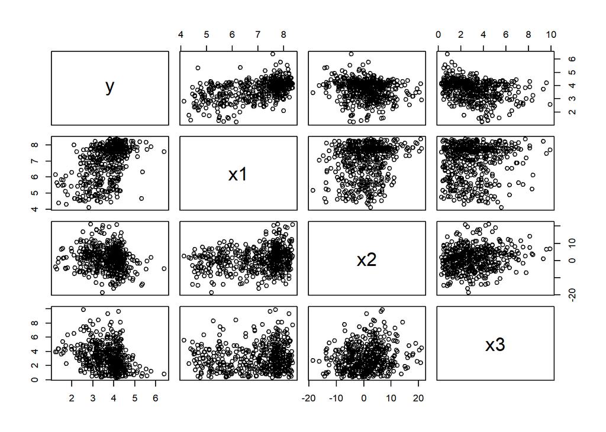

```r
## Matrix of scatterplots
pairs(Norway_NO2[,1:4])
```

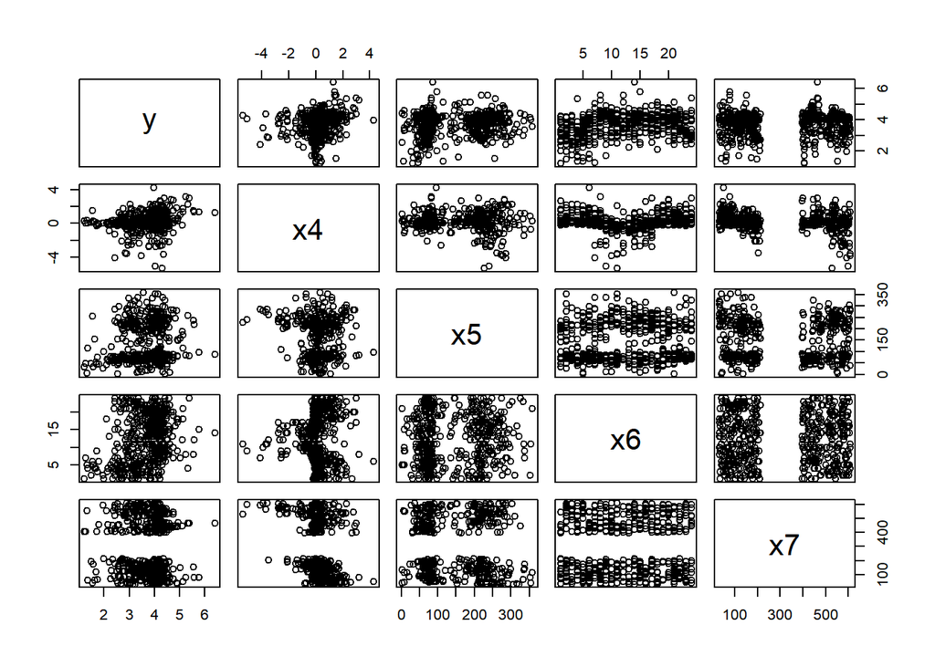

```r
pairs(Norway_NO2[,c(1,5,6,7,8)])
```

1. Which variables seem to have predictive value for *N**O*<sub>2</sub> emissions?
1. Based on the plots, variable x1, x3 and x6 seem to have a relation with *N**O*<sub>2</sub>.

Now, perform a linear regression with wind speed (x3) as explanatory variable and NO2 concentration as the response:

```r
##  Perform a simple linear regression
lm1 <-lm(y ~ x3, data = Norway_NO2)
summary(lm1)
```

```
Call:
lm(formula = y ~ x3, data = Norway_NO2)

Residuals:
     Min       1Q   Median       3Q      Max
-2.36134 -0.43961  0.09015  0.49461  2.38936

Coefficients:
            Estimate Std. Error t value Pr(>|t|)
(Intercept)  4.12143    0.06300  65.423  < 2e-16 ***
x3          -0.13848    0.01781  -7.777  4.3e-14 ***
---
Signif. codes:  0 '***' 0.001 '**' 0.01 '*' 0.05 '.' 0.1 ' ' 1

Residual standard error: 0.7097 on 498 degrees of freedom
Multiple R-squared:  0.1083,    Adjusted R-squared:  0.1065
F-statistic: 60.48 on 1 and 498 DF,  p-value: 4.302e-14
```

```r
anova(lm1)
```

```
Analysis of Variance Table

Response: y
           Df  Sum Sq Mean Sq F value    Pr(>F)
x3          1  30.463 30.4630  60.482 4.302e-14 ***
Residuals 498 250.827  0.5037
---
Signif. codes:  0 '***' 0.001 '**' 0.01 '*' 0.05 '.' 0.1 ' ' 1
```

2. What is the estimated regression parameter for wind speed and its standard error?
3. Is the relation positive or negative and is it what you would expect?
2. The estimated regression parameter for wind speed amounts to -0.138. Its estimated standard error is 0.0178.
3. The relation is negative and this is what you would generally expect: With higher wind speeds you would expect more pollutant dispersion. Indeed, higher pollutant concentrations are generally observed during low wind speed conditions.

Now, fit the model with all 7 predictor variables:

```r
## multiple linear regression model with all 7 predictors
lmmulti <-lm(y ~ x1 + x2 + x3 + x4+ x5 + x6 + x7, data = Norway_NO2)
summary(lmmulti)
```

```
Call:
lm(formula = y ~ x1 + x2 + x3 + x4 + x5 + x6 + x7, data = Norway_NO2)

Residuals:
     Min       1Q   Median       3Q      Max
-2.26475 -0.29962  0.02323  0.34466  1.81446

Coefficients:
              Estimate Std. Error t value Pr(>|t|)
(Intercept)  0.5714178  0.1883834   3.033  0.00255 **
x1           0.5051719  0.0283335  17.829  < 2e-16 ***
x2          -0.0238964  0.0042888  -5.572 4.16e-08 ***
x3          -0.1254828  0.0139549  -8.992  < 2e-16 ***
x4           0.1673639  0.0262239   6.382 4.04e-10 ***
x5           0.0007839  0.0002985   2.626  0.00890 **
x6          -0.0195843  0.0043724  -4.479 9.33e-06 ***
x7           0.0003635  0.0001233   2.947  0.00336 **
---
Signif. codes:  0 '***' 0.001 '**' 0.01 '*' 0.05 '.' 0.1 ' ' 1

Residual standard error: 0.526 on 492 degrees of freedom
Multiple R-squared:  0.5161,    Adjusted R-squared:  0.5092
F-statistic: 74.96 on 7 and 492 DF,  p-value: < 2.2e-16
```

```r
anova(lmmulti)
```

```
Analysis of Variance Table

Response: y
           Df  Sum Sq Mean Sq  F value    Pr(>F)
x1          1  73.623  73.623 266.1047 < 2.2e-16 ***
x2          1  21.644  21.644  78.2292 < 2.2e-16 ***
x3          1  33.120  33.120 119.7087 < 2.2e-16 ***
x4          1   7.721   7.721  27.9082 1.914e-07 ***
x5          1   1.564   1.564   5.6518  0.017819 *
x6          1   5.093   5.093  18.4077 2.148e-05 ***
x7          1   2.403   2.403   8.6863  0.003358 **
Residuals 492 136.122   0.277
---
Signif. codes:  0 '***' 0.001 '**' 0.01 '*' 0.05 '.' 0.1 ' ' 1
```

4. Give the percentage of variation explained by the model. Based on this value, do you expect that the model has predictive value?
5. Give the value of the F test and its corresponding p-value.
6. What is the null hypothesis of this test? And what is the alternative hypothesis of this test? Also give your conclusion based on this test.
7. Can you give the estimated regression equation?
8. What is the value and the meaning of the intercept?
9. Can you test if wind speed has any predictive value (after correction for the effects of all other factors).
10. Compare the RSE, the estimated slope and the corresponding standard error for wind speed of the model with only wind speed (as obtained previously) and the model with all variables. What has changed and why?
11. Which of the other independent variables show a significant association with the NO2 concentration?
4. The adjusted *R*<sup>2</sup> is 0.51. Hence, the combined predictors explain 51% of the variation in *N**O*<sub>2</sub> concentration. We then indeed expect some predictive value for this model.
5. F = 74.96 with p < .0001.
6. The null hypothesis of this test is: *H*<sub>0</sub> : *β*<sub>1</sub> = *β*<sub>2</sub> = *β*<sub>3</sub> = *β*<sub>4</sub> = *β*<sub>5</sub> = *β*<sub>6</sub> = *β*<sub>7</sub> = 0. The alternative hypothesis postulates that: At least one *β*<sub>*j*</sub> ≠ 0. Based on the associated p-value we reject *H*<sub>0</sub>. Hence, at least one of the explanatory variables has a slope that differs from zero.
7. The estimated regression equations is:

E(y)=.57+.505×x1−.024×x2−.125×x3+.167×x4+.00078×x5–.020×x6+.00036×x7.

Say we want to predict the concentration of *N**O*<sub>2</sub> at reasonable values of wind speed. The code below makes a new dataframe by keeping all other variables constant at their mean value. You can add reasonable values for wind speed in the vector c(……). We can also give the corresponding 95% confidence interval for the new predictions.

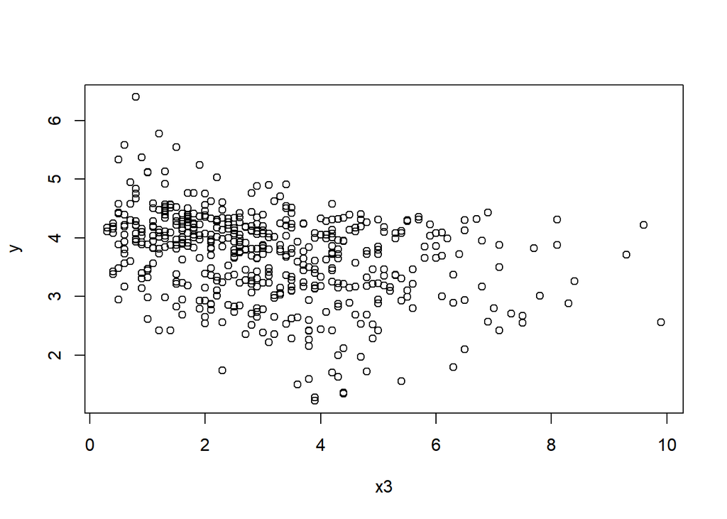

```r
## Predict the concentration of NO2 at a wind speed of ...
par(mfrow = c(1,1))
plot (y ~ x3, data=Norway_NO2)
```

```r
# newdata <- data.frame(x3= c(......))
newdata <- data.frame(x1 = mean(Norway_NO2$x1), x2 = mean(Norway_NO2$x2),
                      x3 = c(2,4,6,8),
                      x4 = mean(Norway_NO2$x4), x5 = mean(Norway_NO2$x5),
                      x6 = mean(Norway_NO2$x6), x7 = mean(Norway_NO2$x7))
predict(lmmulti,newdata , se.fit = TRUE, interval = "confidence")
```

```
$fit
       fit      lwr      upr
1 3.830730 3.776191 3.885269
2 3.579764 3.526792 3.632737
3 3.328799 3.235783 3.421814
4 3.077833 2.934613 3.221053

$se.fit
         1          2          3          4
0.02775794 0.02696074 0.04734114 0.07289315

$df
[1] 492

$residual.scale
[1] 0.5259948
```

It is always important to check the assumptions underlying a model. Hence, we are going to do so, by making some relevant plots:

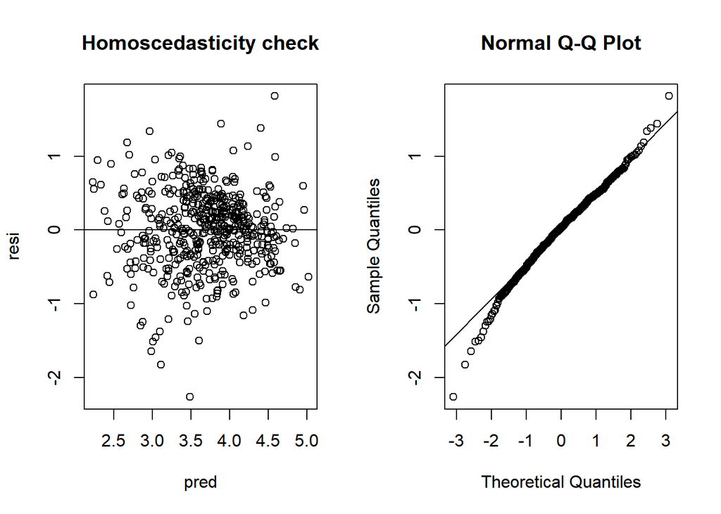

```r
## Residuals and fitted values
resi <- residuals(lmmulti)
pred <- fitted(lmmulti)

## Allowing two side-by-side plots
par(mfrow = c(1,2))

## Scatterplot of residual vs predicted values
plot(resi ~ pred)
abline(h = 0)
title ("Homoscedasticity check")

## Normal Q-Q plot
qqnorm(resi)
qqline(resi)
```

12. What is your conclusion based on these plots?
12. The variance seems reasonably stable over the predictions. hence, equal variance is an acceptable assumption. The bulk of the points fall on the line in the QQ-plot. Some deviations in the tails is acceptable. Hence, normality is also a reasonable assumption.